# Probability Assignment

Matthias Nijman - S4667999

December 7th 2025

# Instructions

- You should submit a single PDF file through Brightspace. If you decide to work on the markdown template provided, knit it to PDF and submit it. Make sure the R code snippets are compiled.
- A penalty will be applied to late submissions. Submissions more than 5 days late will not be accepted.
- Whenever you use R, you should include the code and its output.
- You are encouraged to use R to help answer the questions, although it is not required. However, you must also provide clear explanations of your reasoning. Submitting only R code, even if it produces the correct answer, will not be sufficient to receive full credit.
- This is an individual assignment. Do not copy it from someone or somewhere, and do not share your work with anyone else! If fraud is suspected (e.g., if your answers are too similar to the answers of someone else) the Board of Examiners will be notified.
- The deadline is 07 December 2025, 23:59 CET.

# Questions

## Question 1

Write R code to answer all the questions related to the tips. You can get started working on this question using the RMarkdown template posted on Brightspace. You should refer to the help file of the dataset to know about the variables. This will help you answer the questions.

Let us first load the dataset and the libraries we will use: You can add your R code between the triple quotations!!!

```r
library(tidyverse)
library(MASS)
library(dplyr)
library(ggplot2)
library(reshape2)
data("tips",package='reshape2')
as.data.frame(tips)
```

### a. Find the number of people who visited the restaurant.

```r
tips %>%
summarise(parties = n(), people = sum(size))
```

| parties | people |
| --- | --- |
| 244 | 627 |

The number of people that visited the restaurant is 627, made up of 244 different groups.

### b. Create a column called tip_rate that would show the proportion of the tip to the bill and add it to the dataframe.

```r
tips <- tips %>%
mutate(tip_rate = round((tip/total_bill), digits=2))
head(tips)
```

|  | total_bill | tip | sex | smoker | day | time | size | tip_rate |
| --- | --- | --- | --- | --- | --- | --- | --- | --- |
| 1 | 16.99 | 1.01 | Female | No | Sun | Dinner | 2 | 0.06 |
| 2 | 10.34 | 1.66 | Male | No | Sun | Dinner | 3 | 0.16 |
| 3 | 21.01 | 3.50 | Male | No | Sun | Dinner | 3 | 0.17 |
| 4 | 23.68 | 3.31 | Male | No | Sun | Dinner | 2 | 0.14 |
| 5 | 24.59 | 3.61 | Female | No | Sun | Dinner | 4 | 0.15 |
| 6 | 25.29 | 4.71 | Male | No | Sun | Dinner | 4 | 0.19 |

The tip_rate column now shows the proportion of tip/bill rounded to two digits.

### c. If you were to work at this restaurant, which shift on which day would you prefer? Support your response with a plot. *Hint: Your motivation for doing this job until you are hired by a big tech company is making money.*

```r
by_day <- group_by(tips, day)
summarise(by_day, avg_tip = mean(tip)) %>% arrange(desc(avg_tip))
```

| day | avg_tip |
| --- | --- |
| Sun | 3.255132 |
| Sat | 2.993103 |
| Thur | 2.771452 |
| Fri | 2.734737 |

```r
summarise(by_day, avg_tip_rate = mean(tip_rate)) %>% arrange(desc(avg_tip_rate))
```

| day | avg_tip_rate |
| --- | --- |
| Fri | 0.1694737 |
| Sun | 0.1669737 |
| Thur | 0.1611290 |
| Sat | 0.1536782 |

Assuming I get to keep all the tips, I would pick Sunday as my preferred day of work. The average tip rate is right behind that of Friday, with a difference of 0.0025. The actual average tip is the highest on Sunday, $0.26 more than Saturday (second place), and $0.52 more than Friday, which ranks last.

### d. What is the probability that there will be a group of size 6 on sunday for dinner?

```r
prop.table(table(tips$size, tips$day, tips$time))
```

```
, ,  = Dinner


            Fri         Sat         Sun        Thur
  1 0.000000000 0.008196721 0.000000000 0.000000000
  2 0.045081967 0.217213115 0.159836066 0.004098361
  3 0.000000000 0.073770492 0.061475410 0.000000000
  4 0.004098361 0.053278689 0.073770492 0.000000000
  5 0.000000000 0.004098361 0.012295082 0.000000000
  6 0.000000000 0.000000000 0.004098361 0.000000000

, ,  = Lunch


            Fri         Sat         Sun        Thur
  1 0.004098361 0.000000000 0.000000000 0.004098361
  2 0.020491803 0.000000000 0.000000000 0.192622951
  3 0.004098361 0.000000000 0.000000000 0.016393443
  4 0.000000000 0.000000000 0.000000000 0.020491803
  5 0.000000000 0.000000000 0.000000000 0.004098361
  6 0.000000000 0.000000000 0.000000000 0.012295082
```

From the prop table we can read that the probability of a group of six coming in for dinner on a Sunday is 0.004098361.

# Question 2

You are playing a dice game using two six-sided dice. The dice are not fair, but for simplicity, assume that both dice have the same bias. The probability of each side appearing on a single die is:

| Side | 1 | 2 | 3 | 4 | 5 | 6 |
| --- | --- | --- | --- | --- | --- | --- |
| Prob | 0.05 | 0.10 | 0.15 | 0.20 | 0.25 | 0.25 |

The rules of the game are as follows:

- You and the dealer toss a fair coin to decide who starts the game. If the coin lands on Heads, then you start the game. Otherwise, the dealer starts the game.
- You and the dealer each roll two dice with the starter rolling first .
- Let the total sum of your dice be your score.
- The winner is determined as follows:
  - If both players have the same total, the game ends in a tie.
  - If only one player rolls a total of 7 or 11, that player wins immediately.
  - If only one player’s total exceeds 11, the other player wins.
  - If none of the above occurs, the game continues to the next round.

Probabilities, fair coin toss -> unfair die roll:  
- $P(H) = 0.5$ Toss head, you start  
- $P(T) = 0.5$ Toss tails, dealer starts  
- $P(\epsilon_1) = 0.05$ Roll 1  
- $P(\epsilon_2) = 0.10$ Roll 2  
- $P(\epsilon_3) = 0.15$ Roll 3  
- $P(\epsilon_4) = 0.20$ Roll 4  
- $P(\epsilon_5) = 0.25$ Roll 5  
- $P(\epsilon_6) = 0.25$ Roll 6

### a. Calculate the probability mass function of the discrete random variable $T$ representing the total of the dice.

The PMF of rolling two of the described dice:

| i/j | 1 | 2 | 3 | 4 | 5 | 6 | P(X=i) |
| --- | --- | --- | --- | --- | --- | --- | --- |
| 1 | 0.0025 | 0.005 | 0.0075 | 0.01 | 0.0125 | 0.0125 | 0.05 |
| 2 | 0.005 | 0.01 | 0.015 | 0.02 | 0.025 | 0.025 | 0.10 |
| 3 | 0.0075 | 0.015 | 0.0225 | 0.03 | 0.0375 | 0.0375 | 0.15 |
| 4 | 0.01 | 0.02 | 0.03 | 0.04 | 0.05 | 0.05 | 0.20 |
| 5 | 0.0125 | 0.025 | 0.0375 | 0.05 | 0.0625 | 0.0625 | 0.25 |
| 6 | 0.0125 | 0.025 | 0.0375 | 0.05 | 0.0625 | 0.0625 | 0.25 |
| P(X=j) | 0.05 | 0.10 | 0.15 | 0.20 | 0.25 | 0.25 | 1 |

The PMF of $T$:

| i/j | 2 | 3 | 4 | 5 | 6 | 7 | 8 | 9 | 10 | 11 | 12 |
| --- | --- | --- | --- | --- | --- | --- | --- | --- | --- | --- | --- |
| P(T=x) | 0.0025 | 0.01 | 0.025 | 0.05 | 0.0875 | 0.135 | 0.165 | 0.175 | 0.1625 | 0.125 | 0.0625 |

### b. At the end of the first round, what is the probability that *(Make sure that you clearly explain the assumptions you are making to calculate these probabilities.)*:

#### i. The game ends in a tie?

We will define $T_m$ as my total and $T_d$ as the dealers total. The game ends in a tie if both players have the same total. So the probability that the game ends in a tie at the end of the first round can be defined as $P(T_m = T_d)$. For every x we can say that $P(T_m = x)=P(T_d = x)=P(T = x)$, since our dice have the same odds. The probability of both throwing the same x is then defined as $P(T_m = x)P(T_d = x)=P(T = x)^2$. So we can define the probability that the game ends in a tie at the end of the first round as: $P(T_m = T_d)=P(T = 2)^2+P(T = 3)^2+P(T = 4)^2+P(T = 5)^2+P(T = 6)^2+P(T = 7)^2+P(T = 8)^2+$$P(T = 9)^2+P(T = 10)^2+P(T = 11)^2+P(T = 12)^2 =$ $0.0025^2+0.01^2+0.025^2+0.05^2+0.0875^2+0.135^2+0.165^2+0.175^2+0.1625^2+0.125^2+0.0625^2 = 0.1329$

```r
(0.0025)^2 + (0.01)^2 + (0.025)^2 + (0.05)^2 + (0.0875)^2 + (0.135)^2 + (0.165)^2 + (0.175)^2 + (0.1625)^2 + (0.125)^2 + (0.0625)^2
```

```
[1] 0.1329
```

At the end of the first round, the probability that the game ends in a tie is $0.1329$.

#### ii. You win immediately?

With immediately I assume within the first round. In order to win we can either start and roll 7 or 11. Or roll 7 or 11 after the dealer did not. Or the dealer rolls 12. Lets call me starting $P(S_m)$ and me winning $W_m$. $P(W_m) = P(S_m)P(T_m=7\cup T_m=11) + P(S_d)P(T_d \neq 7 \cap T_d\neq 11)P(T_m=7\cup T_m=11) + P(T_d = 12)$.
$P(T_m=7\cup T_m=11) = P(T_m=7)+P(T_m=11) = 0.135 + 0.125 = 0.26$.
$P(S_m) = P(S_d) = 0.5$.
The probability of the dealer rolling anything but a 7 or an 11 is the intersection of not rolling 7 and not rolling 11, thus it is the union of all options apart from 7 or 11: $P(T_d \neq 7 \cap T_d\neq 11) =$$P(T_d=2)+P(T_d=32)+P(T_d=4)+P(T_d=5)+P(T_d=6)+P(T_d=8)+P(T_d=9)+P(T_d=10)+P(T_d=12)=$ $0.0025 + 0.01 + 0.025 + 0.05 + 0.0875 + 0.165 + 0.175 + 0.1625 + 0.0625 = 0.74$

```r
0.0025 + 0.01 + 0.025 + 0.05 + 0.0875 + 0.165 + 0.175 + 0.1625 + 0.0625
```

```
[1] 0.74
```

$P(W_m) = P(S_m)P(T_m=7\cup T_m=11) + P(S_d)P(T_d \neq 7 \cap T_d\neq 11)P(T_m=7\cup T_m=11) + P(T_d = 12)=$ $0.5\times 0.26 + 0.5\times 0.74 \times 0.26 + 0.0625$

```r
0.5*0.26 + 0.5*0.74*0.26 + 0.0625
```

```
[1] 0.2887
```

At the end of the first round, the probability that I win immediately is $0.2887$.

#### iii. The game continues to the next round?

We know the probability of a tie $P(T_m = T_d)$, and the probability of me winning $P(W_m)$. We know the dealer as the same odds to win as me $P(W_m)=P(W_d)$. So the probability that the game continues $P(C) = 1 - (P(T_m = T_d)+P(W_m)+P(W_d)) = 1 - (0.1329 + 0.2887 + 0.2887) = 0.2897$

```r
1 - (0.1329 + 0.2887 + 0.2887)
```

```
[1] 0.2897
```

At the end of the first round, the probability that the game continues to the next round is $0.2897$.

### c. Eventually, what is the probability that *(Make sure that you clearly explain the assumptions you are making to calculate these probabilities.)*:

#### i. The game ends in a tie?

The probability that the game ends in a tie given that the game continued can be defined as $P(T_m = T_d|C)$. However, the odds remain the same every round. Therefore $P(T_m = T_d|C) = P(T_m = T_d) = 0.1329$

The probability the game eventually ends in a tie is $0.1329$.

#### ii. You win immediately?

I am a bit unsure how to interpret ‘immediately’ here, however I will still assume I am meant to win within a round. The probability that I win the game given that the game continued can be defined as $P(W_m|C)$. However, the odds remain the same every round. Therefore $P(W_m|C) = P(W_m) = 0.2887$.

The probability that I win immediately, eventually is $0.2887$.

### d. Is it possible that this game continues forever? Why? Explain.

Technically yes. Every round is played with the same odds. You flip a coin then both players take turns rolling their dice. Every time this happens there is a probability of $0.2897$ that the game continues. This means there is no hard limit on how many rounds the game may go on for.

However, in reality the game will very likely end at some point, as the probability that we get an outcome that causes the game to continue another round every round, is nearing 0. We can run a few samples of the game and track how many rounds the game went on for to see that in reality, the game will end:

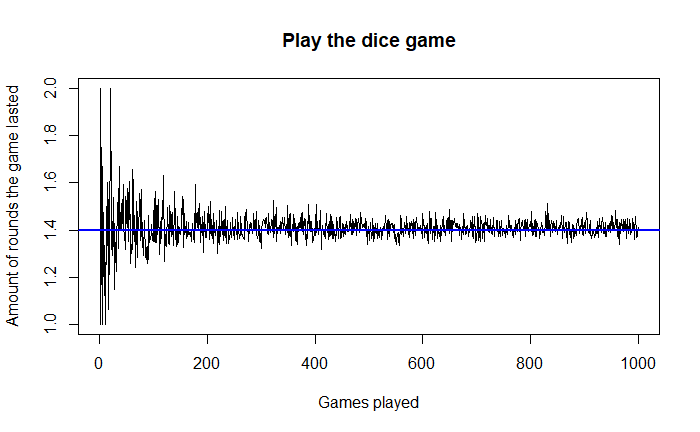

```r
dice_game <- function() {
  outcome <- "C"
  rounds <- 0
  while(outcome == "C"){
    rounds <- rounds +1
    outcome <- sample(x=c("T","M","D","C"), size = 1, prob=c(0.1329, 0.2887, 0.2887, 0.2897))
  }
  return(rounds)
}

play_dice_game <- function(n) {
  return(mean(replicate(n, dice_game())))
}

set.seed(1)
results <- sapply(1:1000, play_dice_game)
plot(results, type='l', main="Play the dice game", xlab="Games played", ylab="Amount of rounds the game lasted")
abline(h = 1.4, col = "blue", lwd=2)
```

We can see that on average the game lasts roughly 1.4 rounds, no where near infinity.

*Hint: You may use simulation to calculate the probabilities. Particularly, we highly recommend using R for the probability distribution of $T$.*

## Question 3:

A company has developed a “Marten Car Alarm Detector”, designed to alert car owners when malicious stone martens are chewing on the cables of their vehicles. In northern Europe, there are $500{,}000$ stone martens, but only $500$ are estimated to tamper with cars. To test the product before launching it to the market, a car owner conducts trials:

- The alarm correctly detects a car-tampering marten $99\%$ of the time.
- The alarm incorrectly triggers for a harmless marten $1\%$ of the time.

Let’s say that $A$ is the alarm going off and $M$ is a car tampering stone marten. I will also assume that $500{,}000$ martens go into cars (detected or undetected), otherwise I do not know how to calculate $P(M^c)$.

### a. If the alarm goes off, what is the probability that a stone marten is actually tampering with the car?

We want to know the probability of a tampering stone marten being in the car when the alarm goes off: $P(M|A)$.  
$P(M) = \frac{500}{500000} = 0.001$  
$P(M^c) = 1 - 0.001 = 0.999$  
$P(A|M) = 0.99$ (TP rate)  
$P(A|M^c) = 0.01$ (FP rate)  
Using Bayes’ formula we know that $P(M|A)=\frac{P(A|M)P(M)}{P(A)}$.  
Using the total law of probabilities we know that $P(M|A)=\frac{P(A|M)P(M)}{P(A|M)P(M)+P(A|M^c)P(M^c)}$.  
So $P(M|A)=\frac{0.99 \times 0.001}{0.99\times 0.001+0.01\times 0.999} = 0.09016393$

```r
(0.99*0.001) / (0.99*0.001+0.01*0.999)
```

```
[1] 0.09016393
```

The probability of a tampering stone marten being in the car when the alarm goes off is $0.09016393$.

### b. Based on your calculations, would you, as a car owner, be confident in buying this alarm system?

First of all I want to know how often the alarm fails to warn me for a tempering marten: $P(A^c|M) = 1-0.99 = 0.01$. So we have an alarm that fails to warn me about 1% of the time. On top of that, if it does warn me there is a ($P(M^c|A) = 1-0.09016393=0.90983607$) roughly 90% chance I’m being warned for a harmless marten. I don’t think bullying 9 stone martens away from my car, for every 1 time that I’m saving some repair costs is worth buying this system for. So no, I would not be confident in buying this alarm system. Only someone who hates stone martens would.

## Question 4:

A bubble tea cup is 15 cm tall. Because the tapioca pearls settle toward the bottom, the linear density of pearls (in pearls per cm of height) is given by
$$f(h) = 50 - 2h, \qquad
0 \le h \le 15,$$
where $h$ is the height measured from the bottom of the cup.

### a. How many pearls are in the cup?

We know that the density function is $\int_a^bf(t)dt$. In this case that would be $\int_0^{15}(50-2h)dh$ 0 for the bottom of the cup and 15 for the top.

```r
integrate(function(h)50-2*h, lower = 0, upper = 15)
```

```
525 with absolute error < 5.8e-12
```

There are 525 pearls in the cup.

### b. Let $H$ be the continuous random variable of height of a randomly selected pearl. Find the probability density function of $H$.

The PDF of $H$ is:
$$f(H) =
\begin{cases}
\text{$\frac{50-2h}{525}$}, & \text{if 0 $\leq H \leq$ 15},\\[6pt]
0, & \text{otherwise}.
\end{cases}$$

### c. Find the cumulative distribution function of $H$.

The CDF of $H$ is $P((0, H])$.

### d. If a straw reaches down to a depth of 10 cm, what is the probability that the drinker swallows a pearl?

A depth of 10 cm is the same as a height of $15-10=5 cm$. So $H=5$ in this case. $0\leq 5 \leq 15$ is true, so we can use $\frac{50-2H}{525}$. $\frac{50-2\times 5}{525} = \frac{40}{525} = \frac{8}{105}$.

```r
fractions(40/525)
```

```
[1] 8/105
```

The probability of swallowing a pearl at depth 10 cm, is $\frac{8}{105}$.

## Question 5:

$X$ is the result of rolling a fair 4-sided die and $Y$ is defined as follows:
$$Y =
\begin{cases}
\text{the result of rolling a fair 8-sided die}, & \text{if $X$ is
even},\\[6pt]
X, & \text{if $X$ is odd}.
\end{cases}$$

### a. Verify that $X$ and $Y$ are not independent.

For $X$ and $Y$ to be independent, $P(X = i, Y = j) = P(X = i)P(Y = j)$ must hold. We roll a fair 4-sided die (d4), the result is $X$, if it is odd $Y = X$. If it was even, we roll a fair 8-sided die (d8) and take the result as $Y$. $Y$ can be 1 or 3 by rolling it on the d4 or by rolling 2 or 4 on the d4 and then the 1 or the 3 on the d8. All the other 6 numbers can only be achieved by rolling 2 or 4 on the d4 and then rolling the number on the d8. Thus $P(1) = P(3) = \frac{1}{4} + \frac{2}{4} \times \frac{1}{8} = \frac{5}{16}$ and $P(2) = P(4) = P(5) = P(6) = P(7) = P(8) = \frac{2}{4} \times \frac{1}{8} = \frac{1}{16}$. In order to check independence we can create a PMF table:

| i/j | 1 | 2 | 3 | 4 | 5 | 6 | 7 | 8 | P(X=i) |
| --- | --- | --- | --- | --- | --- | --- | --- | --- | --- |
| 1 | 1/4 | 0 | 0 | 0 | 0 | 0 | 0 | 0 | 1/4 |
| 2 | 1/32 | 1/32 | 1/32 | 1/32 | 1/32 | 1/32 | 1/32 | 1/32 | 1/4 |
| 3 | 0 | 0 | 1/4 | 0 | 0 | 0 | 0 | 0 | 1/4 |
| 4 | 1/32 | 1/32 | 1/32 | 1/32 | 1/32 | 1/32 | 1/32 | 1/32 | 1/4 |
| P(Y=j) | 5/16 | 1/16 | 5/16 | 1/16 | 1/16 | 1/16 | 1/16 | 1/16 | 1 |

We can see that $P(X = i, Y = j) = P(X = i)P(Y = j)$ will not hold. To prove it we can look at an example. $X = 1, Y = 2$ we can see from the table that $P(X = 1, Y = 2) = 0$ meanwhile $P(X = 1)P(Y = 2) = \frac{1}{4}\times \frac{1}{16} = \frac{1}{64}$. Since $0 \neq \frac{1}{64}$, $X$ and $Y$ are not independent.

### b. Find $\mathbb{E}[XY]$.

Lets take $Z = XY$.
$$Z(X, Y) =
\begin{cases}
1, & \text{if } X = 1, \ Y = 1, \\[6pt]
2, & \text{if } X = 2, \ Y = 1, \\[6pt]
4, & \text{if } X = 2, \ Y = 2 \text{ or } X = 4, \ Y = 1, \\[6pt]
6, & \text{if } X = 2, \ Y = 3, \\[6pt]
8, & \text{if } X = 2, \ Y = 4 \text{ or } X = 4, \ Y = 2, \\[6pt]
9, & \text{if } X = 3, \ Y = 3, \\[6pt]
10, & \text{if } X = 2, \ Y = 5, \\[6pt]
12, & \text{if } X = 2, \ Y = 6 \text{ or } X = 4, \ Y = 3, \\[6pt]
14, & \text{if } X = 2, \ Y = 7, \\[6pt]
16, & \text{if } X = 2, \ Y = 8 \text{ or } X = 4, \ Y = 4, \\[6pt]
20, & \text{if } X = 4, \ Y = 5, \\[6pt]
24, & \text{if } X = 4, \ Y = 6, \\[6pt]
28, & \text{if } X = 4, \ Y = 7, \\[6pt]
32, & \text{if } X = 4, \ Y = 8.
\end{cases}$$

$\mathbb{E}[XY] = \mathbb{E}[Z] = (1)P(Z=1)+(2)P(Z=2)+(4)P(Z=4)+(6)P(Z=6)+(8)P(Z=8)+(9)P(Z=9)+(10)P(Z=10)+$ $(12)P(Z=12)+(14)P(Z=14)+(16)P(Z=16)+(20)P(Z=20)+(24)P(Z=24)+(28)P(Z=28)+(32)P(Z=32)=$ $(1)\frac{1}{4}+(2)\frac{1}{32}+(4)(2)\frac{1}{32}+(6)\frac{1}{32}+(8)(2)\frac{1}{32}+(9)\frac{1}{4}+(10)\frac{1}{32})+(12)(2)\frac{1}{32}+(14)\frac{1}{32}+(16)(2)\frac{1}{32}+(20)\frac{1}{32}+(24)\frac{1}{32}+$ $(28)\frac{1}{32}+(32)\frac{1}{32}=9.25$

```r
(1+9)*(1/4) + (2+4+4+6+8+8+10+12+12+14+16+16+20+24+28+32)*((1/32))
```

```
[1] 9.25
```

## Question 6:

Let $W$ be the weight (in kg) of a person in a population, with mean 70 and standard deviation 15. Consider a random sample of $n$ people. Let $\bar{W}_n$ denote the sample mean weight.

### a. What is the distribution that approximates $\bar{W}_n$? Give its parameters. Explain why?

The Poisson distribution approximates $\bar{W}_n$. It has parameter $\lambda > 0$ and $\lambda = Np$. The Poisson distribution approximates the Binomial distribution $\mathcal{P}(Np) \sim \mathcal{B}(Np)$ for large N and small p. Where $N$ is the number of trials and $p$ is their probability. The Binomial distribution is the actual distribution of $\bar{W}_n$. So if the Poisson distribution approximates the Binomial distribution, the Poisson distribution approximates $\bar{W}_n$.

### b. Using R, approximate the probability that the sample mean weight is between 75 kg and 80 kg for the following sample sizes:

#### i. $n = 100$

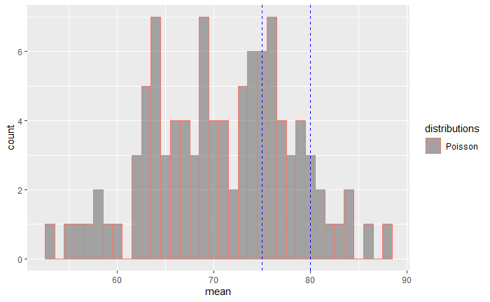

```r
set.seed(1)
poisson_dist<- rpois(100,70)
df <- data.frame("Poisson"=poisson_dist)
df_long <- gather(data=df,key=distributions,value=mean,Poisson)
ggplot(df_long,aes(x=mean,color=distributions)) + geom_histogram(position = "identity",alpha = 0.5,binwidth=1) +
  geom_vline(xintercept = c(75, 80), linetype="dashed", color = "blue")
```

```r
sum(poisson_dist >= 75 & poisson_dist <= 80) / 100
```

```
[1] 0.27
```

The probability of the sample mean weight being between 75 and 80 for n=100 is $0.27$.

#### ii. $n = 1000$

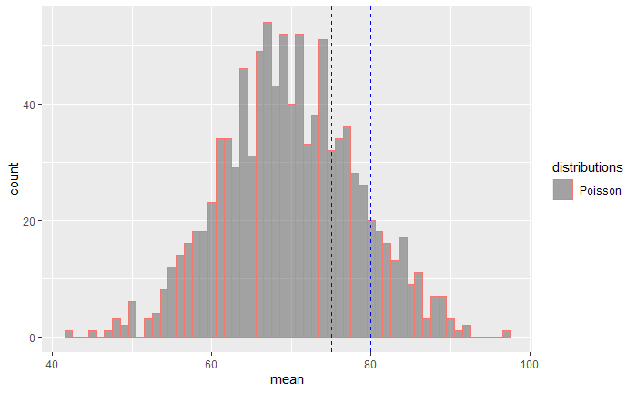

```r
set.seed(1)
poisson_dist<- rpois(1000,70)
df <- data.frame("Poisson"=poisson_dist)
df_long <- gather(data=df,key=distributions,value=mean,Poisson)
ggplot(df_long,aes(x=mean,color=distributions)) + geom_histogram(position = "identity",alpha = 0.5,binwidth=1) +
  geom_vline(xintercept = c(75, 80), linetype="dashed", color = "blue")
```

```r
sum(poisson_dist >= 75 & poisson_dist <= 80) / 1000
```

```
[1] 0.176
```

The probability of the sample mean weight being between 75 and 80 for n=1000 is $0.176$.

#### iii. $n = 10000$

[figure not shown]

```r
set.seed(1)
poisson_dist<- rpois(10000,70)
df <- data.frame("Poisson"=poisson_dist)
df_long <- gather(data=df,key=distributions,value=mean,Poisson)
ggplot(df_long,aes(x=mean,color=distributions)) + geom_histogram(position = "identity",alpha = 0.5,binwidth=1) +
  geom_vline(xintercept = c(75, 80), linetype="dashed", color = "blue")
```

```r
sum(poisson_dist >= 75 & poisson_dist <= 80) / 10000
```

```
[1] 0.1829
```

The probability of the sample mean weight being between 75 and 80 for n=10000 is $0.1829$.

### c. Discuss how the probability changes as the sample size increases.

As stated before the Poisson distribution approximates the Binomial distribution $\mathcal{P}(Np) \sim \mathcal{B}(Np)$ for large N and small p. And the Binomial distribution is the actual distribution of $\bar{W}_n$. This means that as the sample size ($N$) grows, the approximated probability becomes closer to the actual probability, it becomes more accurate. Ideally we take $N = \infty$, but since this is not possible, it is best to take $N$ as large as possible, to make your approximation more accurate.